# Machine learning – Random Forrests + Data Analysis

### PCA Variable Contributions

The correlation between a variable and a principal component (PC) is used as the coordinates of the variable on the PC. The contribution represents the proportion of a variable’s contribution to a given principal component, expressed as a percentage.

- Positively correlated variables are grouped together.
- Negatively correlated variables are positioned on opposite sides of the plot origin (opposed quadrants).

Variables that are correlated with PC1 and PC2 are the most important in explaining the variability in the data set.

Information adapted from the detailed study of Principal Component Analysis available at: https://f0nzie.github.io/machine_learning_compilation/detailed-study-of-principal-component-analysis.html

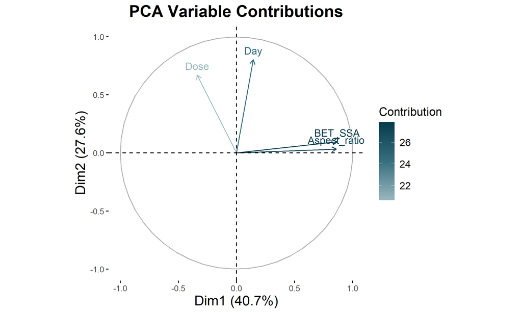

### PCA Biplot

A biplot simultaneously presents the distribution of observations and the contribution of variables. Four key pieces of information can be extracted from it:

1. Distribution of observations: The distance between points indicates the similarity between observations—observations that are closer together are more similar with respect to the variables.
2. Contribution of variables: The direction of the vectors indicates the direction in which the variables have the greatest influence on the principal components, while the length of the vector reflects the strength of this influence. The longer the vector, the stronger the contribution of the variable to the respective component.
3. Relationships between variables: Variables represented by vectors in the same direction are positively correlated, whereas those in opposite directions exhibit negative correlation. Variables that are orthogonal to each other are independent (uncorrelated).
4. Interactions between observations and variables: It is also possible to observe how individual variables influence the positioning of observations in the principal component space. Observations that are close to a given variable’s vector have a high value for that variable.

[figure not shown]

### Results

```r
# Metrics
R2Q2 <- function(experimental, predicted) {
  return(1 - sum((experimental - predicted)^2, na.rm = TRUE) / sum((experimental - mean(experimental, na.rm = TRUE))^2, na.rm = TRUE))
}
RMSE <- function(experimental, predicted) {
  return(sqrt(mean((experimental - predicted)^2, na.rm = TRUE)))
}

# Grid parameters
set.seed(8)

SampizePerc <- floor(nrow(AutoscDescT) * c(0.5, 0.7, 0.9, 1))

grid <- expand.grid(ntree = c(500, 750, 1000),
                    mtry = seq(2, 4, by = 1),
                    nodesize = c(1, 5, 10, 20),
                    sampsize = SampizePerc,
                    maxnodes = seq(5, 25, by = 5))

# Table for resuts
results <- data.frame(ntree = numeric(), mtry = numeric(), nodesize = numeric(), sampsize = numeric(), maxnodes = numeric(), Q2 = numeric(), RMSEext = numeric(), R2 = numeric(), RMSEext = numeric())

# Grid search
for (i in 1:nrow(grid)) {
  params <- grid[i,]
    set.seed(8)
    model <- randomForest(x = AutoscDescT, RespTrain,
                          ntree = params$ntree,
                          mtry = params$mtry,
                          nodesize = params$nodesize,
                          sampsize = params$sampsize,
                          maxnodes = params$maxnodes,
                          replace = TRUE,
                          importance = TRUE,
                          do.trace = FALSE)

    RespTrainPred <- predict(model, newdata = AutoscDescT)
    RespValPred <- predict(model, newdata = AutoscDescV)

    R2 <- R2Q2(RespTrain, RespTrainPred)
    RMSEc <- RMSE(RespTrain, RespTrainPred)
    Q2 <- R2Q2(RespVal, RespValPred)
    RMSEext <- RMSE(RespVal, RespValPred)

  # First selection
  if (Q2 > 0.85) {
  results <- rbind(results, data.frame(ntree = params$ntree,
                                       mtry = params$mtry,
                                       nodesize = params$nodesize,
                                       sampsize = params$sampsize,
                                       maxnodes = params$maxnodes,
                                       Q2 = Q2,
                                       RMSEext = RMSEext,
                                       R2 = R2,
                                       RMSEc = RMSEc))
  }
}

# The secon selection
ResultSort <- results[order(-results$Q2), ]
BestRes <- head(ResultSort)

print(BestRes)
```

```
##     ntree mtry nodesize sampsize maxnodes        Q2  RMSEext        R2    RMSEc
## 499   500    2       10      189       25 0.8881863 1.597905 0.9402197 1.315028
## 463   500    2       10      170       25 0.8868944 1.607110 0.9378810 1.340504
## 500   750    2       10      189       25 0.8856782 1.615727 0.9398878 1.318673
## 464   750    2       10      170       25 0.8854597 1.617270 0.9372759 1.347017
## 501  1000    2       10      189       25 0.8854090 1.617628 0.9395259 1.322637
## 465  1000    2       10      170       25 0.8851622 1.619369 0.9367859 1.352269
```

The primary evaluation of a model relies on the R² and Q² parameters. R² measures how well the data fit the model, while Q² assesses its predictive power. A key threshold for both is 0.7—values above this indicate good data fit and strong predictive performance. Additionally, the difference between R² and Q² matters; if it exceeds 0.3, it may signal overfitting. For example, with Q² = 0.89 and R² = 0.94, the model’s performance is considered satisfactory. The RMSEc (Root Mean Squared Error of calibration) and RMSEext (Root Mean Squared Error of validation) values should be as low as possible and close to each other.

### Leave-One-Out Cross-Validation

The Leave-One-Out Cross-Validation (LOO CV) method is particularly useful for small to medium-sized datasets, as it can be computationally intensive. The method works by sequentially excluding one data point from the training set, recalibrating the model, and then making a prediction for the excluded point. The model’s statistics, such as Qcv and RMSEext, follow the same principles as the calibration and external validation statistics described earlier. These metrics help determine whether the model is stable and robust against the removal of individual data points.

```r
#Table for results
resultscv <- data.frame(ntree = numeric(), mtry = numeric(), nodesize = numeric(), sampsize = numeric(), maxnodes = numeric(), Q2cv = numeric(), RMSEcv = numeric())

# Loop for parameters
for (i in 1:nrow(BestRes)) {
  HypParm <- BestRes[i, ]

  TrainPredLoo <- numeric(length(RespTrain))
  # Loop for crossvalidation
  for (j in 1:length(RespTrain)) {
    TrainIndicates <- setdiff(1:length(RespTrain), j)
    TrainSetLoo <- AutoscDescT[TrainIndicates, ]
    RespTrainLoo <- RespTrain[TrainIndicates]
    ValSetLoo <- AutoscDescT[j, , drop = FALSE]
    RespValLoo <- RespTrain[j]

    set.seed(8)
    # In the training set, there is one less element.
    sampsizevalue <- HypParm$sampsize - 1

    model <- randomForest(x = TrainSetLoo, y = RespTrainLoo,
                          ntree = HypParm$ntree,
                          mtry = HypParm$mtry,
                          nodesize = HypParm$nodesize,
                          sampsize = sampsizevalue,
                          maxnodes = HypParm$maxnodes,
                          replace = TRUE,
                          importance = TRUE,
                          do.trace = FALSE)

    PredLoo <- predict(model, newdata = ValSetLoo)

    TrainPredLoo[j] <- PredLoo
  }
  Q2cv <- R2Q2(RespTrain, TrainPredLoo)
  RMSEcv <- RMSE(RespTrain, TrainPredLoo)

  resultscv <- rbind(resultscv, data.frame(ntree = HypParm$ntree,
                                       mtry = HypParm$mtry,
                                       nodesize = HypParm$nodesize,
                                       sampsize = HypParm$sampsize,
                                       maxnodes = HypParm$maxnodes,
                                       Q2cv = Q2cv,
                                       RMSEcv = RMSEcv))
}

ResultsAll<- cbind(resultscv, Q2ext = BestRes$Q2, RMSEext = BestRes$RMSEext, R2 = BestRes$R2, RMSEc = BestRes$RMSEc)
print(ResultsAll)
```

```
##   ntree mtry nodesize sampsize maxnodes      Q2cv   RMSEcv     Q2ext  RMSEext
## 1   500    2       10      189       25 0.8909174 1.776372 0.8881863 1.597905
## 2   500    2       10      170       25 0.8893823 1.788827 0.8868944 1.607110
## 3   750    2       10      189       25 0.8922938 1.765129 0.8856782 1.615727
## 4   750    2       10      170       25 0.8902143 1.782087 0.8854597 1.617270
## 5  1000    2       10      189       25 0.8918840 1.768483 0.8854090 1.617628
## 6  1000    2       10      170       25 0.8898139 1.785334 0.8851622 1.619369
##          R2    RMSEc
## 1 0.9402197 1.315028
## 2 0.9378810 1.340504
## 3 0.9398878 1.318673
## 4 0.9372759 1.347017
## 5 0.9395259 1.322637
## 6 0.9367859 1.352269
```

### The best model

```r
# Function for MAE calculation
MAE <- function(experimental, predicted) {
  mean(abs(experimental - predicted), na.rm = TRUE)
}

# Training
set.seed(8)
FinalModel <- randomForest(x = AutoscDescT, y = RespTrain,
                           ntree = HypParm$ntree,
                           mtry = HypParm$mtry,
                           nodesize = HypParm$nodesize,
                           sampsize = sampsizevalue,
                           maxnodes = HypParm$maxnodes,
                           replace = TRUE,
                           importance = TRUE,
                           do.trace = FALSE)

RespTrainPred <- predict(FinalModel, newdata = AutoscDescT)
RespValPred <- predict(FinalModel, newdata = AutoscDescV)

ResidualsTrain <- RespTrain - RespTrainPred
ResidualsVal <- RespVal - RespValPred

R2 <- ResultsAll$R2[1]
RMSEc <- ResultsAll$RMSEc[1]
MAEt <- MAE(RespTrain, RespTrainPred)
Q2ext <- ResultsAll$Q2ext[1]
RMSEext <- ResultsAll$RMSEext[1]
Q2cv <- ResultsAll$Q2cv[1]
RMSEcv <- ResultsAll$RMSEcv[1]

SummaryModel <- cbind(Summary, PredictedTox = c(RespTrainPred, RespValPred), Residuals = c(ResidualsTrain, ResidualsVal))
print(head(SummaryModel))
```

```
##        ChemName Dose Day Aspect_ratio BET_SSA Autoscaled_Dose Autoscaled_Day
## 1   Flamruss101  162  90      1.00000   23.00     -0.09542867    -0.12967475
## 2          DQ12  162 180      1.00000   10.10     -0.09542867    -0.08686715
## 3          DQ12   18   3      1.00000   10.10     -0.16392083    -0.17105543
## 279   NanoFil 9  162   1    300.00000   24.07     -0.09542867    -0.17200671
## 280   NRCWE-006   18   1     77.02703   26.00     -0.16392083    -0.17200671
## 281   NRCWE-006   18   3     77.02703   26.00     -0.16392083    -0.17105543
##     Autoscaled_Aspect_ratio Autoscaled_BET_SSA Experimental Set PredictedTox
## 1               -0.17200671         -0.1615426         1.65   T     2.963129
## 2               -0.17200671         -0.1676784         1.80   T     2.954673
## 3               -0.17200671         -0.1676784         2.00   T     3.832904
## 279             -0.02979035         -0.1610337        24.50   T    20.842396
## 280             -0.13584521         -0.1601157        26.60   T    22.364593
## 281             -0.13584521         -0.1601157        28.40   T    21.532345
##     Residuals
## 1   -1.313129
## 2   -1.154673
## 3   -1.832904
## 279  3.657604
## 280  4.235407
## 281  6.867655
```

```r
print(tail(SummaryModel))
```

```
##            ChemName Dose Day Aspect_ratio BET_SSA Autoscaled_Dose
## 262       Bentonite   18   3     83.33333   73.59     -0.16392083
## 265 NanoFil 3000 Se   18   3    300.00000    2.74     -0.16392083
## 268       NRCWE-006   54   3     77.02703   26.00     -0.14679779
## 271 NanoFil 3000 Se   54   1    300.00000    2.74     -0.14679779
## 274       NanoFil 9  162   3    300.00000   24.07     -0.09542867
## 277       NRCWE-006   54   1     77.02703   26.00     -0.14679779
##     Autoscaled_Day Autoscaled_Aspect_ratio Autoscaled_BET_SSA Experimental Set
## 262     -0.1710554             -0.13284568         -0.1374800        18.20   V
## 265     -0.1710554             -0.02979035         -0.1711791        18.95   V
## 268     -0.1710554             -0.13584521         -0.1601157        19.50   V
## 271     -0.1720067             -0.02979035         -0.1711791        20.00   V
## 274     -0.1710554             -0.02979035         -0.1610337        21.90   V
## 277     -0.1720067             -0.13584521         -0.1601157        22.85   V
##     PredictedTox     Residuals
## 262     18.19996  3.736875e-05
## 265     18.15789  7.921096e-01
## 268     20.90565 -1.405651e+00
## 271     18.64054  1.359455e+00
## 274     19.67781  2.222190e+00
## 277     21.93975  9.102540e-01
```

```r
print(paste("Results of model: R2 = ", round(R2, 2), "RMSEc = ", round(RMSEc, 2), "Q2ext = ", round(Q2ext, 2), "RMSEext = ", round(RMSEext, 2), "Q2cv = ", round(Q2cv, 2), "RMSEcv =", round(RMSEcv, 2), "MAE = ", round(MAEt, 2)))
```

```
## [1] "Results of model: R2 =  0.94 RMSEc =  1.32 Q2ext =  0.89 RMSEext =  1.6 Q2cv =  0.89 RMSEcv = 1.78 MAE =  0.98"
```

### Residual density

In a well-fitting model, the residuals should follow a normal distribution.

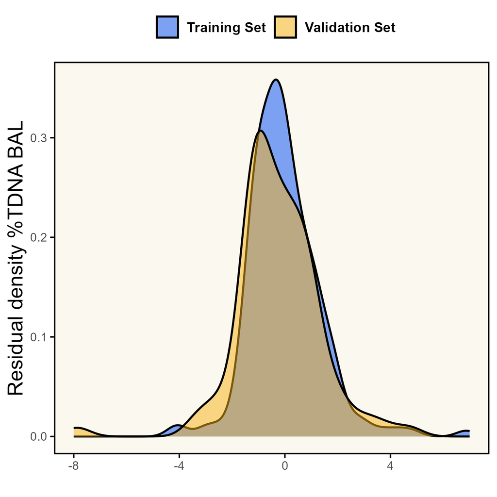

```r
MaxDens <- as.numeric(ceiling(max(SummaryModel$Residuals)))
MinDens <- as.numeric(floor(min(SummaryModel$Residuals)))

# The first plot
DensityPlot <- ggdensity((SummaryModel),
                          x = "Residuals",
                          size = 0.7,
                          fill = "Set",
                          palette = c("#004AF5", "#F7B213")) +
  scale_x_continuous(limits = c(MinDens, MaxDens)) +
  scale_fill_manual(values = c("T" = "#004AF5", "V" = "#F7B213"),
                    labels = c("Training Set", "Validation Set"))

DensityPlot <- ggpar(DensityPlot, legend.title = "", legend = "top", xlab = "",
                      ylab = "Residual density %TDNA BAL", ggtheme = theme_bw())

DensityPlot <- DensityPlot +
  theme(panel.grid.major = element_blank(),
        panel.grid.minor = element_blank(),
        panel.border = element_rect(colour = "black", size = 1),
        panel.background = element_rect(fill = "#faf8ef"),
        axis.title.y = element_text(size = 15),
        legend.text = element_text(face = "bold", size = 10))

# Save Residual density plot to PNG
ggsave("docs/figures/ResDens.png", plot = DensityPlot, width = 1500, height = 1500, units = "px", dpi = 300)
```

### Observed versus predicted plot

Scatter plot of experimentally determined versus predicted values. The straight line indicates a perfect match between the experimental and predicted values.

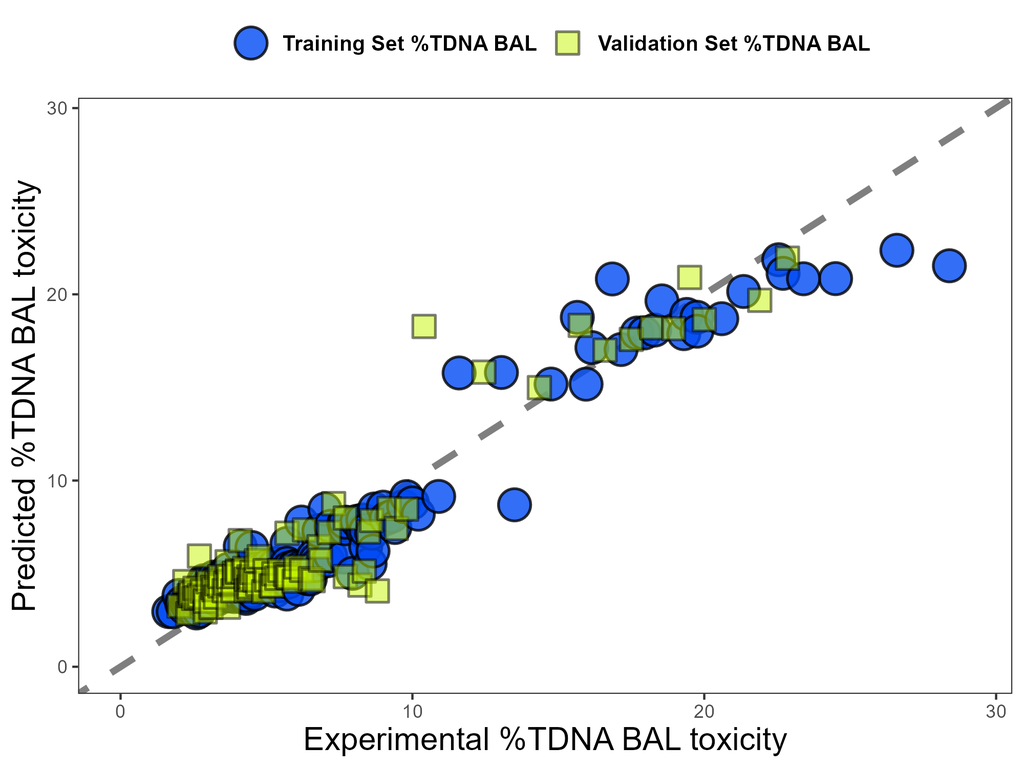

```r
# Selection of columns for analysis
ObvsPred <- SummaryModel[(ncol(SummaryModel) - 3):(ncol(SummaryModel) - 1)]
MaxRespo <- as.numeric(ceiling(max(ObvsPred[, c(1, 3)], na.rm = TRUE))) + 0.1

# Plot
ObvsPredPlot <- ggplot(ObvsPred) +
  geom_abline(intercept = 0, slope = 1, linetype = "dashed", colour = "#7F7F7F", alpha = 1, size = 1.5) +

  geom_point(data = subset(ObvsPred, Set == "T"),
             aes(x = Experimental, y = PredictedTox, fill = "Training Set %TDNA BAL", shape = "Training Set %TDNA BAL"),
             size = 6.5, alpha = 0.8, stroke = 0.9) +

  geom_point(data = subset(ObvsPred, Set == "V"),
             aes(x = Experimental, y = PredictedTox, fill = "Validation Set %TDNA BAL", shape = "Validation Set %TDNA BAL"),
             size = 5, alpha = 0.5, stroke = 0.9) +
  theme_bw() +
  xlab(paste("Experimental %TDNA BAL toxicity")) +
  ylab(paste("Predicted %TDNA BAL toxicity")) +
  theme(axis.title.x = element_text(size = 15),
        axis.title.y = element_text(size = 15)) +
  scale_x_continuous(limits = c(0, MaxRespo)) +
  scale_y_continuous(limits = c(0, MaxRespo)) +
  scale_fill_manual(name = "",
                    values = c("Training Set %TDNA BAL" = "#004AF5",
                               "Validation Set %TDNA BAL" = "#c5f500")) +
  scale_shape_manual(name = "",
                     values = c("Training Set %TDNA BAL" = 21,
                                "Validation Set %TDNA BAL" = 22)) +
  theme(legend.position = "top",
        legend.text = element_text(face = "bold", size = 10),
        panel.grid.major = element_blank(),
        panel.grid.minor = element_blank())

# Save Residual density plot to PNG
ggsave("docs/figures/ObvsPredPlot.png", plot = ObvsPredPlot, width = 2000, height = 1500, units = "px", dpi = 300)
```

### William’s plot

A Williams plot offers a visual representation of this relationship, plotting leverage values against cross-validated standardized residuals to identify response outliers and/or structurally distinct chemicals that fall outside the applicability domain. The critical leverage value (h* ), representing the cut-off distance from the centroid, is generally set at h* = 3(M + 1)/N, where M is the number of descriptors (i.e., independent variables) in the model, and N is the number of TS compounds. The boundaries of the applicability domain with respect to the response space were defined by the limit of ±3 standardized residuals. Predictions were considered reliable and trustworthy, providing a high level of assurance only when the query compound fell within a square area bounded by ±3 standard deviation units and the leverage threshold (h*).

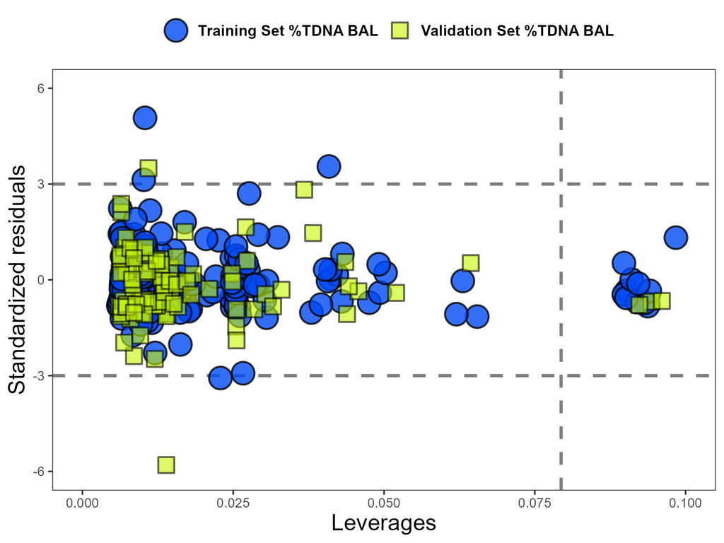

```r
#Leverage threshold
h_l <- 3*(ncol(AutoscDescT)+1)/nrow(AutoscDescT)

TrainMatrix <- data.matrix(AutoscDescT)
ValMatrix <- data.matrix(AutoscDescV)
TrainMatrixT <- t(TrainMatrix)
MultpMatrix <- TrainMatrixT %*% TrainMatrix
InvMatrix <- solve(MultpMatrix)

hTrainValue <- numeric()

# Leverage values
for (idx in 1:nrow(TrainMatrix)) {
  xi_t <- t(as.matrix(TrainMatrix[idx, ]))
  xi <- as.matrix(TrainMatrix[idx, ])
  hi <- xi_t %*% InvMatrix %*% xi
  hTrainValue <- c(hTrainValue, hi)
}

hValValue <- numeric()

for (idx in 1:nrow(ValMatrix)) {
  xi_v <- t(as.matrix(ValMatrix[idx,]))
  xi <- as.matrix(ValMatrix[idx,])
  hi <- xi_v %*% InvMatrix %*% xi
  hValValue <- c(hValValue, hi)
}

# Standardized residuals
StandResTrain <- rep(NA, length(ResidualsTrain))

NaIdxT1 <- !is.na(ResidualsTrain)
StandResTrain[NaIdxT1] <- autoscale(ResidualsTrain[NaIdxT1], ResidualsTrain[NaIdxT1])

StandResVal <- rep(NA, length(ResidualsVal))

NaIdxV1 <- !is.na(ResidualsVal)
StandResVal[NaIdxV1] <- autoscale(ResidualsVal[NaIdxV1], ResidualsTrain[NaIdxT1])

TrainAD <- cbind(hTrainValue, StandResTrain)
ValAD <- cbind(hValValue, StandResVal)
ADdata <- cbind(as.data.frame(rbind(TrainAD, ValAD)), Set = SummaryModel$Set)

MaxLev <- as.numeric(ceiling(max(ADdata[,1]) * 10) / 10)
MaxSRes <- abs(as.numeric(ceiling(max(ADdata[,2]))))
MinSRes <- abs(as.numeric(floor(min(ADdata[,2]))))
StRes <- max(MaxSRes, MinSRes)

# Plot
WilliamsPlot <- ggplot() +
  geom_hline(yintercept = c(-3, 3), linetype = "dashed", colour = "#7F7F7F", alpha = 1, size = 1) +
  geom_vline(xintercept = h_l, linetype = "dashed", colour = "#7F7F7F", alpha = 1, size = 1) +

  geom_point(data = subset(ADdata, Set == "T"),
             aes(x = hTrainValue, y = StandResTrain, fill = "Training Set %TDNA BAL", shape = "Training Set %TDNA BAL"),
             size = 6.5, alpha = 0.8, stroke = 0.9) +

  geom_point(data = subset(ADdata, Set == "V"),
             aes(x = hTrainValue, y = StandResTrain, fill = "Validation Set %TDNA BAL", shape = "Validation Set %TDNA BAL"),
             size = 5, alpha = 0.6, stroke = 0.9) +

  theme_bw() +
  xlab(paste("Leverages")) +
  ylab(paste("Standardized residuals")) +
  scale_x_continuous(limits = c(0, MaxLev)) +
  scale_y_continuous(limits = c(-StRes, StRes)) +
  scale_fill_manual(name = "",
                    values = c("Training Set %TDNA BAL" = "#004AF5",
                               "Validation Set %TDNA BAL" = "#c5f500")) +
  scale_shape_manual(name = "",
                     values = c("Training Set %TDNA BAL" = 21,
                                "Validation Set %TDNA BAL" = 22)) +
  theme(axis.title.x = element_text(size = 15),
        axis.title.y = element_text(size = 15),
        legend.position = "top",
        legend.text = element_text(face = "bold", size = 10),
        panel.grid.major = element_blank(),
        panel.grid.minor = element_blank())

# Save WilliamsPlot to PNG
ggsave("docs/figures/WilliamsPlot.png", plot = WilliamsPlot, width = 2000, height = 1500, units = "px", dpi = 300)
```